# Chap5_10

J.H AHN

2021 12 9

## 5.10 Time series cross-validation

training set과 test set으로 나누는 방법을 좀 더 정교하게 하기 위한 것이 시계열 교차 검증(time series cross-validation)이다.  
교차검증에는 단일 관측값으로 구성된 일련의 test set이 있고 해당 training set은 test set을 구성하는 관측치 이전 관측치로만 구성된다.  
따라서 training set으로 모델을 만들 때 (training set 기준으로) 미래의 관측값은 사용되지 않는다.  
training set이 작으면 신뢰할 만한 예측 모델을 만들 수 없기 때문에 첫 번째 관측치들은 test set으로 간주하지 않는다.

이를 쉽게 표현한 그림이 있다.  
파란색은 training set, 주황색은 test set의 관측치를 의미한다.

[figure not shown]

예측 정확도는 test set으로 평가한 결과의 평균으로 계산된다.  
이렇게 하는 이유는 예측의 기반이 되는 기준점(training set과 test set이 나눠지는 시점)이 시간에 따라 뒤로 밀리기(roll forward) 때문에 “evaluation on a rolling forecasting origin”라고 표현되기도 한다.

시계열 예측에서는 one-step forecast이 multi-step forecast와 관련이 없을 수도 있다.  
이런 경우 rolling forecasting origin에 기반한 교차 검증을 수행하여 오류를 줄일 수 있다.  
만약 4-step forecasts를 한다고 가정해보자.

[figure not shown]

일단 구글 주식 예시를 그대로 가져온다.

```r
# Re-index based on trading days
google_stock <-
    gafa_stock %>%
    filter(Symbol == "GOOG", year(Date) >= 2015) %>%
    mutate(day = row_number()) %>%
    update_tsibble(index = day, regular = TRUE)

# Filter the year of interest
google_2015 <-
    google_stock %>%
    filter(year(Date) == 2015)

google_2015
```

```
## # A tsibble: 252 x 9 [1]
## # Key:       Symbol [1]
##    Symbol Date        Open  High   Low Close Adj_Close  Volume   day
##    <chr>  <date>     <dbl> <dbl> <dbl> <dbl>     <dbl>   <dbl> <int>
##  1 GOOG   2015-01-02  526.  528.  521.  522.      522. 1447600     1
##  2 GOOG   2015-01-05  520.  521.  510.  511.      511. 2059800     2
##  3 GOOG   2015-01-06  512.  513.  498.  499.      499. 2899900     3
##  4 GOOG   2015-01-07  504.  504.  497.  498.      498. 2065100     4
##  5 GOOG   2015-01-08  495.  501.  488.  500.      500. 3353600     5
##  6 GOOG   2015-01-09  502.  502.  492.  493.      493. 2069400     6
##  7 GOOG   2015-01-12  492.  493.  485.  490.      490. 2322400     7
##  8 GOOG   2015-01-13  496.  500.  490.  493.      493. 2370500     8
##  9 GOOG   2015-01-14  492.  500.  490.  498.      498. 2235700     9
## 10 GOOG   2015-01-15  503.  503.  495.  499.      499. 2715800    10
## # ... with 242 more rows
```

가져온 구글 주식 데이터로 시계열 교차 검증을 통해 정확도와 잔차 정확도를 비교해 본다.  
`stretch_tsibble()`함수는 training set의 길이를 늘려준다. 아래 예시에는 training set 길이가 `.init=3`에서 시작하여 `step=1`씩 늘어나도록 한 것이다.  
(첫 번째 training set은 3일치 주가가 들어가고, 두 번째 training set은 1일이 늘어난 4일치 주가가 들어가는 방식으로 늘려가게 한 것)

```r
# Time series cross-validation accuracy
google_2015_tr <-
    google_2015 %>%
    stretch_tsibble(.init = 3, .step = 1) %>%
    relocate(Date, Symbol, .id)

google_2015_tr
```

```
## # A tsibble: 31,875 x 10 [1]
## # Key:       Symbol, .id [250]
##    Date       Symbol   .id  Open  High   Low Close Adj_Close  Volume   day
##    <date>     <chr>  <int> <dbl> <dbl> <dbl> <dbl>     <dbl>   <dbl> <int>
##  1 2015-01-02 GOOG       1  526.  528.  521.  522.      522. 1447600     1
##  2 2015-01-05 GOOG       1  520.  521.  510.  511.      511. 2059800     2
##  3 2015-01-06 GOOG       1  512.  513.  498.  499.      499. 2899900     3
##  4 2015-01-02 GOOG       2  526.  528.  521.  522.      522. 1447600     1
##  5 2015-01-05 GOOG       2  520.  521.  510.  511.      511. 2059800     2
##  6 2015-01-06 GOOG       2  512.  513.  498.  499.      499. 2899900     3
##  7 2015-01-07 GOOG       2  504.  504.  497.  498.      498. 2065100     4
##  8 2015-01-02 GOOG       3  526.  528.  521.  522.      522. 1447600     1
##  9 2015-01-05 GOOG       3  520.  521.  510.  511.      511. 2059800     2
## 10 2015-01-06 GOOG       3  512.  513.  498.  499.      499. 2899900     3
## # ... with 31,865 more rows
```

`.id`열은 몇 번째 training set인지를 나타내는 새로운 key이다.  
`accuracy()`함수는 training set의 예측 정확도를 평가하는데 사용할 수 있다.

```r
# TSCV accuracy
google_2015_tr %>%
    model(RW(Close ~ drift())) %>%
    forecast(h=1) %>%
    accuracy(google_2015) %>%
    select(c(".type","RMSE","MAE","MAPE","MASE"))
```

```
## # A tibble: 1 x 5
##   .type  RMSE   MAE  MAPE  MASE
##   <chr> <dbl> <dbl> <dbl> <dbl>
## 1 Test   11.3  7.26  1.19  1.02
```

```r
# Training set accuracy
google_2015 %>%
    model(RW(Close ~ drift())) %>%
    accuracy() %>%
    select(c(".type","RMSE","MAE","MAPE","MASE"))
```

```
## # A tibble: 1 x 5
##   .type     RMSE   MAE  MAPE  MASE
##   <chr>    <dbl> <dbl> <dbl> <dbl>
## 1 Training  11.1  7.16  1.18  1.00
```

예상대로 전체 데이터로 예측한 것이 RMSE가 더 작게 나온다. (전체 데이터를 사용했으니 당연한 결과임.)

### Example: Forecast horizon accuracy with cross-validation

아래는 구글의 주가 데이터를 이용해서 1~8 step ahead drift값을 주었을 때 예측 성능이 어떻게 변화하는지 확인한 것이다.  
당연하게도 예측 범위가 커질수록(as the forecast horizon increases) 오차가 커지는 것을 확인할 수 있다.

```r
fc <- google_2015_tr %>%
    model(RW(Close ~ drift())) %>%
    forecast(h = 8) %>%
    group_by(.id) %>%
    mutate(h = row_number()) %>%
    ungroup()

fc
```

```
## # A fable: 2,000 x 7 [1]
## # Key:     Symbol, .id, .model [250]
##    Symbol   .id .model                day        Close .mean     h
##    <chr>  <int> <chr>               <dbl>       <dist> <dbl> <int>
##  1 GOOG       1 RW(Close ~ drift())     4 N(488, 0.47)  488.     1
##  2 GOOG       1 RW(Close ~ drift())     5  N(476, 1.4)  476.     2
##  3 GOOG       1 RW(Close ~ drift())     6  N(465, 2.8)  465.     3
##  4 GOOG       1 RW(Close ~ drift())     7  N(454, 4.7)  454.     4
##  5 GOOG       1 RW(Close ~ drift())     8    N(442, 7)  442.     5
##  6 GOOG       1 RW(Close ~ drift())     9  N(431, 9.8)  431.     6
##  7 GOOG       1 RW(Close ~ drift())    10   N(420, 13)  420.     7
##  8 GOOG       1 RW(Close ~ drift())    11   N(408, 17)  408.     8
##  9 GOOG       2 RW(Close ~ drift())     5   N(490, 37)  490.     1
## 10 GOOG       2 RW(Close ~ drift())     6   N(483, 99)  483.     2
## # ... with 1,990 more rows
```

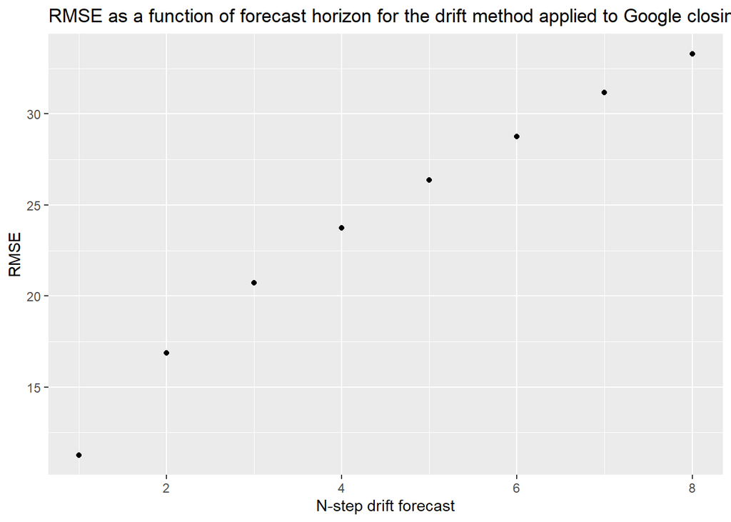

```r
fc %>%
    accuracy(google_2015, by = c("h", ".model")) %>%
    ggplot(aes(x = h, y = RMSE)) +
    geom_point() +
    labs(x = "N-step drift forecast", y = "RMSE",
         title = "RMSE as a function of forecast horizon for the drift method applied to Google closing stock prices")
```